# Week 3 - Logistic regression

```r
date()
```

```
## [1] "Sat Nov 20 12:43:23 2021"
```

## Introduction

This week, we are analyzing and modeling data on two questionnaires related to student performance and alcohol consumption. Further description is available [here](https://archive.ics.uci.edu/ml/datasets/Student+Performance). Since the description is relevant for analysis we reprint it verbatim:

“*This data approach student achievement in secondary education of two Portuguese schools. The data attributes include student grades, demographic, social and school related features) and it was collected by using school reports and questionnaires. Two datasets are provided regarding the performance in two distinct subjects: Mathematics (mat) and Portuguese language (por). In [Cortez and Silva, 2008], the two datasets were modeled under binary/five-level classification and regression tasks. Important note: the target attribute G3 has a strong correlation with attributes G2 and G1. This occurs because G3 is the final year grade (issued at the 3rd period), while G1 and G2 correspond to the 1st and 2nd period grades. It is more difficult to predict G3 without G2 and G1, but such prediction is much more useful (see paper source for more details).*”

The dataset has been preprocessed by joining data from two courses, Math and Portugese language. Variables `alc_use` and `high_use` have been added in the wrangling phase.

## Dataset

Begin by loading the analysis data. Let’s use the “official” csv-file; an R script to produce the wrangled data is in the [repo](https://github.com/kuuravar/IODS-project).

```r
rm(list=ls())

# read in the data, convert strings to factors
alc <- read.csv("https://github.com/rsund/IODS-project/raw/master/data/alc.csv",
                header = TRUE, sep = ",", stringsAsFactors = TRUE)

dim(alc)
```

```
## [1] 370  51
```

There are 370 rows and 51 columns.

```r
str(alc)
```

```
## 'data.frame':    370 obs. of  51 variables:
##  $ school    : Factor w/ 2 levels "GP","MS": 1 1 1 1 1 1 1 1 1 1 ...
##  $ sex       : Factor w/ 2 levels "F","M": 1 1 1 1 1 1 1 1 1 1 ...
##  $ age       : int  15 15 15 15 15 15 15 15 15 15 ...
##  $ address   : Factor w/ 2 levels "R","U": 1 1 1 1 1 1 1 1 1 2 ...
##  $ famsize   : Factor w/ 2 levels "GT3","LE3": 1 1 1 1 1 1 1 2 2 1 ...
##  $ Pstatus   : Factor w/ 2 levels "A","T": 2 2 2 2 2 2 2 2 2 1 ...
##  $ Medu      : int  1 1 2 2 3 3 3 2 3 3 ...
##  $ Fedu      : int  1 1 2 4 3 4 4 2 1 3 ...
##  $ Mjob      : Factor w/ 5 levels "at_home","health",..: 1 3 1 4 4 4 4 2 3 3 ...
##  $ Fjob      : Factor w/ 5 levels "at_home","health",..: 3 3 3 2 4 2 5 4 3 2 ...
##  $ reason    : Factor w/ 4 levels "course","home",..: 2 4 4 1 4 1 1 4 4 4 ...
##  $ guardian  : Factor w/ 3 levels "father","mother",..: 2 2 2 2 3 2 1 2 1 1 ...
##  $ traveltime: int  2 1 1 1 2 1 2 2 2 1 ...
##  $ studytime : int  4 2 1 3 3 3 3 2 4 4 ...
```

[output cut: 37 more lines]

Seems like there are mostly integer and character (factorized) valued variables, as well as at least one logical (`high_use`) and float (`alc_use`).

```r
# (Type for factor is int.)
table(sapply(alc, typeof))
```

```
##
##  double integer logical
##       1      49       1
```

```r
# Check for zero variance (negate characters to get "not all duplicated")
sort(
  sapply(alc, function(x) {
    ifelse(is.numeric(x), var(x), !all(duplicated(x)[-1L]))
    }))
```

```
##            n   failures.p     failures   traveltime   failures.m    studytime
## 0.000000e+00 2.398667e-01 3.109939e-01 4.916502e-01 5.049513e-01 7.189922e-01
##         Dalc       famrel     freetime      alc_use       school          sex
## 8.032594e-01 8.304695e-01 9.712224e-01 9.958178e-01 1.000000e+00 1.000000e+00
##      address      famsize      Pstatus         Mjob         Fjob       reason
## 1.000000e+00 1.000000e+00 1.000000e+00 1.000000e+00 1.000000e+00 1.000000e+00
##     guardian    schoolsup       famsup   activities      nursery       higher
## 1.000000e+00 1.000000e+00 1.000000e+00 1.000000e+00 1.000000e+00 1.000000e+00
##     internet     romantic         paid       paid.p       paid.m     high_use
## 1.000000e+00 1.000000e+00 1.000000e+00 1.000000e+00 1.000000e+00 1.000000e+00
##         Medu         Fedu        goout          age         Walc       health
## 1.173984e+00 1.179697e+00 1.273720e+00 1.393987e+00 1.666366e+00 1.981220e+00
##         G2.p         G1.p           G1           G2         G3.p           G3
## 6.078518e+00 6.512854e+00 7.301699e+00 7.914627e+00 8.665092e+00 1.080868e+01
##         G1.m         G2.m         G3.m   absences.p     absences   absences.m
## 1.119153e+01 1.444749e+01 2.124131e+01 2.330626e+01 3.029392e+01 5.876224e+01
##          cid         id.m         id.p
## 1.143917e+04 1.274368e+04 3.041907e+04
```

```r
# Seems OK, only `n` has zero variance.
```

## Variables correlated to alcohol consumption

Let’s apply a data-driven approach to discover the top 4 variables linked to the alcohol consumption. Intuitively, family relationships and characteristics, study time, grades, and peer behavior should have an effect.

We want to compute association between all the variables. To allow for factors, we employ a stackoverflow solution

```r
# From
# https://stackoverflow.com/questions/52554336/plot-the-equivalent-of-correlation-matrix-for-factors-categorical-data-and-mi/56485520#56485520

library(tidyverse)
library(rcompanion)


# Calculate a pairwise association between all variables in a data-frame. In particular nominal vs nominal with Chi-square, numeric vs numeric with Pearson correlation, and nominal vs numeric with ANOVA.
# Adopted from https://stackoverflow.com/a/52557631/590437
mixed_assoc = function(df, cor_method="spearman", adjust_cramersv_bias=TRUE){
    df_comb = expand.grid(names(df), names(df),  stringsAsFactors = F) %>% set_names("X1", "X2")

    is_nominal = function(x) class(x) %in% c("factor", "character")
    # https://community.rstudio.com/t/why-is-purr-is-numeric-deprecated/3559
    # https://github.com/r-lib/rlang/issues/781
    is_numeric <- function(x) { is.integer(x) || is_double(x)}

    f = function(xName,yName) {
        x =  pull(df, xName)
        y =  pull(df, yName)

        result = if(is_nominal(x) && is_nominal(y)){
            # use bias corrected cramersV as described in https://rdrr.io/cran/rcompanion/man/cramerV.html
            cv = cramerV(as.character(x), as.character(y), bias.correct = adjust_cramersv_bias)
            data.frame(xName, yName, assoc=cv, type="cramersV")

        }else if(is_numeric(x) && is_numeric(y)){
            correlation = cor(x, y, method=cor_method, use="complete.obs")
            data.frame(xName, yName, assoc=correlation, type="correlation")

        }else if(is_numeric(x) && is_nominal(y)){
            # from https://stats.stackexchange.com/questions/119835/correlation-between-a-nominal-iv-and-a-continuous-dv-variable/124618#124618
            r_squared = summary(lm(x ~ y))$r.squared
            data.frame(xName, yName, assoc=sqrt(r_squared), type="anova")

        }else if(is_nominal(x) && is_numeric(y)){
            r_squared = summary(lm(y ~x))$r.squared
            data.frame(xName, yName, assoc=sqrt(r_squared), type="anova")

        }else {
            warning(paste("unmatched column type combination: ", class(x), class(y)))
        }

        # finally add complete obs number and ratio to table
        result %>% mutate(complete_obs_pairs=sum(!is.na(x) & !is.na(y)), complete_obs_ratio=complete_obs_pairs/length(x)) %>% rename(x=xName, y=yName)
    }

    # apply function to each variable combination
    map2_df(df_comb$X1, df_comb$X2, f)
}
```

Then we can use the function for correlations

```r
# remove boolean high_use (or recode it to integer/factor)
mixed.cors <- mixed_assoc(alc[, -which(names(alc) %in% c("high_use"))])
```

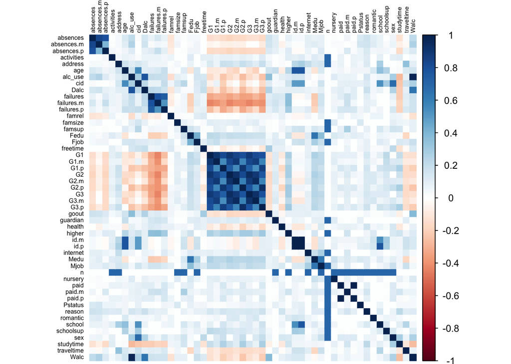

```r
library(corrplot)

cor.matrix <-
  mixed.cors %>%
  select(x, y, assoc) %>%
  spread(y, assoc) %>%
  select(-x) %>%
  replace(is.na(.), 0)

rownames(cor.matrix) <- colnames(cor.matrix)

corrplot(as.matrix(cor.matrix), method = "color",
         tl.cex = 0.5, tl.col = "black")
```

From the correlation plot, we see that, as expected by definition, `Dalc` and `Walc` correlate positively with `alc_use`. It would be interesting to include these for further analysis to explain the drinking behavior. Since we’re limited to four variables, we choose a coarse approach and only take `alc_use`.

The grade variables correlate negatively with `alc_use`; based on the data annotation in the beginning, it is easiest to choose `G3` for further analysis. The `famrel` correlates negatively with `alc_use`, and seems quite interesting. `goout`, `sex` and `studytime` are interesting as well. Let’s make sure these variables don’t correlate too much.

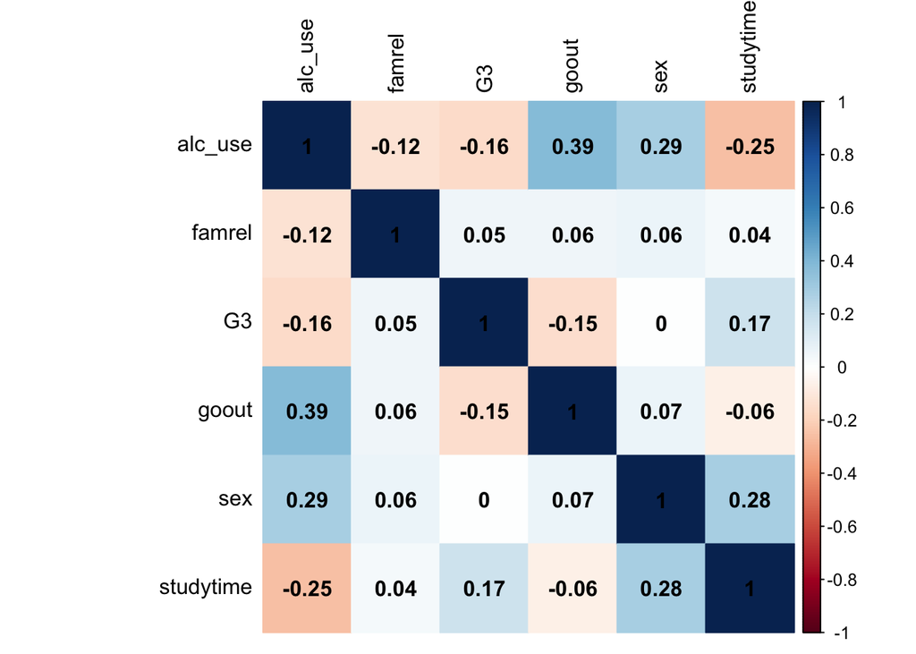

```r
interesting_vars <- c("alc_use", "G3", "famrel", "goout", "sex", "studytime")

cor.matrix <-
  alc %>%
    select(interesting_vars) %>%
    mixed_assoc(cor_method = "pearson") %>%
    select(x, y, assoc) %>%
    spread(y, assoc) %>%
    select(-x)

rownames(cor.matrix) <- colnames(cor.matrix)

corrplot(as.matrix(cor.matrix), method = "color",
         tl.cex = 1, tl.col = "black", addCoef.col = 'black')
```

Seems good!

```r
# Select the subset
alc.sub <- alc[, interesting_vars]

str(alc.sub)
```

```
## 'data.frame':    370 obs. of  6 variables:
##  $ alc_use  : num  1 3 1 1 2.5 1 2 2 2.5 1 ...
##  $ G3       : int  12 8 12 9 12 12 6 10 16 10 ...
##  $ famrel   : int  3 3 4 4 4 4 4 4 4 4 ...
##  $ goout    : int  2 4 1 2 1 2 2 3 2 3 ...
##  $ sex      : Factor w/ 2 levels "F","M": 1 1 1 1 1 1 1 1 1 1 ...
##  $ studytime: int  4 2 1 3 3 3 3 2 4 4 ...
```

## Further exploration

Begin with the GGally::ggpairs

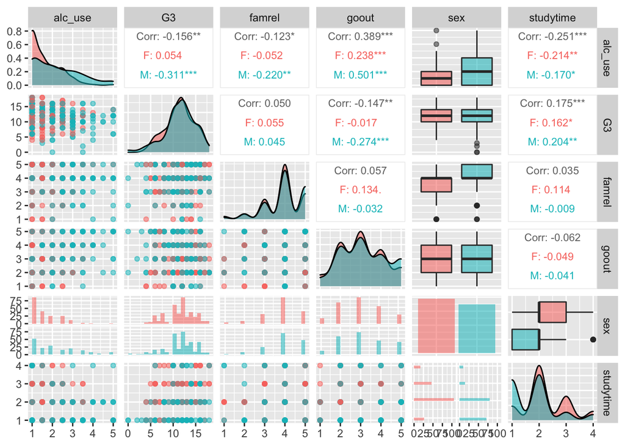

```r
library(GGally)
library(ggplot2)

p <- ggpairs(alc.sub, mapping = aes(col = sex, alpha = 0.3),
             lower = list(combo = wrap("facethist", bins = 20)),
             upper = list(continuous = wrap("cor", size = 3)))

p
```

We see that

- There is approximately equal number of males (n=175) and females (n=195)
- Males tend to use more alcohol
- Distribution of grade `G3` is similar for both sexes, and is not normal (by shapiro.test()), has a peak and is left skewed
- `famrel` correlates with `alc_use`, but significantly only for males
- Males report better quality family relationships
- Males use less time for studying
- `goout` correlates positively with alcohol use with a high significance
- `studytime` correlates negatively with alcohol use with a high significance

All in all, there are several hypotheses

- Getting a better grade while being male is associated with lower alcohol use
- Family relationships affect alcohol use
- Alcohol is used when going out
- Alcohol is not used when studying

Let’s take a closer look on the quality of family relationship versus alcohol use

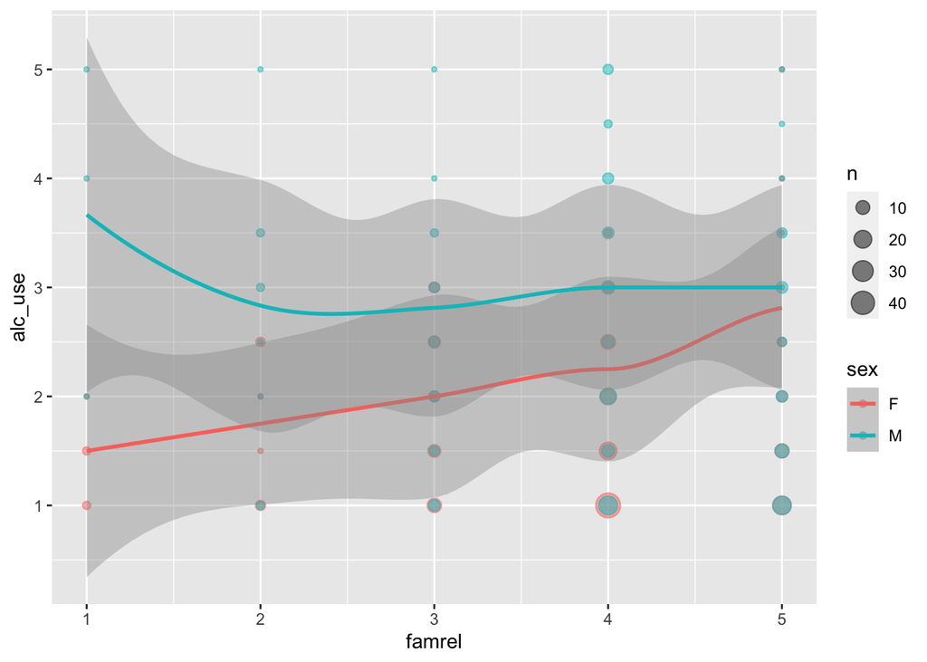

```r
library(tidyverse)

alc_var <- function(alc, expl.variable) {
  expl.vars <- c(expl.variable, "alc_use", "sex")

  # Tidyverse black magic
  res <-
    alc %>%
      select(one_of(expl.vars)) %>%
      count(!!!sapply(expl.vars, as.symbol))

  g <- ggplot(res, aes(x = .data[[expl.variable]], y = alc_use, col = sex)) +
    geom_point(aes(size = n), alpha = 0.5) + geom_smooth(method = "loess")

  return(g)
}

alc_var(alc, "famrel")
```

With a bit of caution, it appears than men with low quality `famrel` use more alcohol, as there is an increase in `alc_use` when `famrel` goes from medium to bad. However, the relationship is roughly linear (without deep analysis):

```r
summary(lm(alc_use ~ famrel, data = alc[alc$sex == "M", ]))
```

```
##
## Call:
## lm(formula = alc_use ~ famrel, data = alc[alc$sex == "M", ])
##
## Residuals:
##     Min      1Q  Median      3Q     Max
## -1.7458 -0.9118 -0.1898  0.8102  3.0882
##
## Coefficients:
##             Estimate Std. Error t value Pr(>|t|)
## (Intercept)  3.30184    0.38377   8.604 4.55e-15 ***
## famrel      -0.27800    0.09368  -2.968  0.00343 **
## ---
## Signif. codes:  0 '***' 0.001 '**' 0.01 '*' 0.05 '.' 0.1 ' ' 1
##
## Residual standard error: 1.128 on 173 degrees of freedom
## Multiple R-squared:  0.04844,    Adjusted R-squared:  0.04294
## F-statistic: 8.807 on 1 and 173 DF,  p-value: 0.003427
```

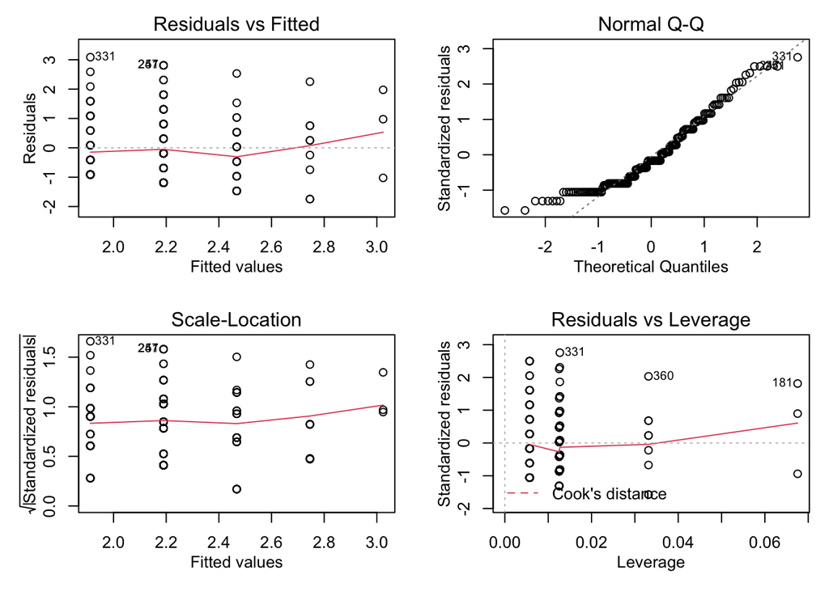

```r
# make the plot tighter
op <- par(mfrow=c(2, 2),
          mar = c(4, 4, 2, 1),
          mgp = c(2, 1, 0))

plot(lm(alc_use ~ famrel, data = alc[alc$sex == "M", ]))

par(op) # return original par
```

```r
library(car)
# There is no heteroscedasticity by Breusch-Pagan test
car::ncvTest(lm(alc_use ~ famrel, data = alc[alc$sex == "M", ]))
```

```
## Non-constant Variance Score Test
## Variance formula: ~ fitted.values
## Chisquare = 0.398195, Df = 1, p = 0.52802
```

Next, plot the other variables as well

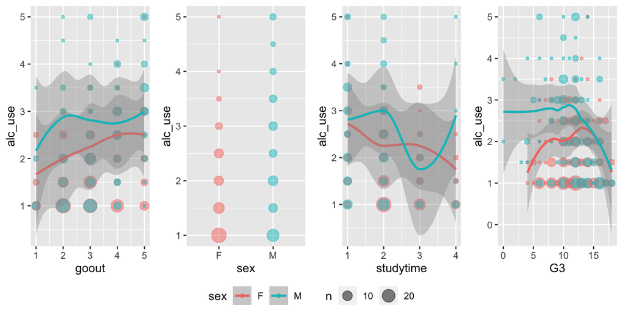

```r
library(ggpubr)

g1 <- alc_var(alc, "goout")
g2 <- alc_var(alc, "sex")
g3 <- alc_var(alc, "studytime")
g4 <- alc_var(alc, "G3")

ggarrange(g1, g2, g3, g4,
          ncol = 4, nrow = 1, common.legend = TRUE,
          legend = "bottom")
```

When `goout` increases, so does the alcohol use. Males appear to use more alcohol. As `studytime` increases, alcohol usage drops. `G3` does not have a clear linear pattern with alcohol use. Otherwise, the above hypotheses are OK.

## Logistic regression

Now we are ready to fit the logistic regression model with `G3`, `famrel`, `goout`, `sex` and `studytime`.

```r
model.1 <- glm(paste0("high_use", " ~ ", paste(interesting_vars[-1], collapse=" + ")),
               family = "binomial", data = alc)

summary(model.1)
```

```
##
## Call:
## glm(formula = paste0("high_use", " ~ ", paste(interesting_vars[-1],
##     collapse = " + ")), family = "binomial", data = alc)
##
## Deviance Residuals:
##     Min       1Q   Median       3Q      Max
## -1.6895  -0.7784  -0.4891   0.8155   2.6807
##
## Coefficients:
##             Estimate Std. Error z value Pr(>|z|)
## (Intercept) -0.85026    0.85893  -0.990  0.32222
## G3          -0.03667    0.04031  -0.910  0.36294
## famrel      -0.41604    0.13989  -2.974  0.00294 **
## goout        0.77038    0.12402   6.212 5.25e-10 ***
## sexM         0.80171    0.26695   3.003  0.00267 **
## studytime   -0.46034    0.17229  -2.672  0.00754 **
## ---
## Signif. codes:  0 '***' 0.001 '**' 0.01 '*' 0.05 '.' 0.1 ' ' 1
##
## (Dispersion parameter for binomial family taken to be 1)
##
##     Null deviance: 452.04  on 369  degrees of freedom
## Residual deviance: 369.86  on 364  degrees of freedom
## AIC: 381.86
##
## Number of Fisher Scoring iterations: 4
```

We got a model with four significant variables. Interestingly, `G3` is not significant, remove it and refit.

```r
model.2 <- glm(high_use ~ famrel + goout + sex + studytime,
               family = "binomial", data = alc)

summary(model.2)
```

```
##
## Call:
## glm(formula = high_use ~ famrel + goout + sex + studytime, family = "binomial",
##     data = alc)
##
## Deviance Residuals:
##     Min       1Q   Median       3Q      Max
## -1.5891  -0.7629  -0.4976   0.8304   2.6937
##
## Coefficients:
##             Estimate Std. Error z value Pr(>|z|)
## (Intercept)  -1.2672     0.7312  -1.733  0.08309 .
## famrel       -0.4193     0.1399  -2.996  0.00273 **
## goout         0.7873     0.1230   6.399 1.57e-10 ***
## sexM          0.7959     0.2669   2.982  0.00286 **
## studytime    -0.4814     0.1711  -2.814  0.00490 **
## ---
## Signif. codes:  0 '***' 0.001 '**' 0.01 '*' 0.05 '.' 0.1 ' ' 1
##
## (Dispersion parameter for binomial family taken to be 1)
##
##     Null deviance: 452.04  on 369  degrees of freedom
## Residual deviance: 370.69  on 365  degrees of freedom
## AIC: 380.69
##
## Number of Fisher Scoring iterations: 4
```

There is a lot of output

- Fitted model is $log \frac{Pr(high\_use =1)}{ 1 - Pr(high\_use = 1)} = log \frac{Pr(high\_use =1)}{Pr(high\_use = 0)} = -1.2672 - 0.4193*famrel + 0.7873 * goout + 0.7959 * sexM - 0.4814 * studytime$
- The coefficients represent a change in the log odds of the response when the explanatory variable increases by one, conditional on the other explanatory variables remaining constant
- All of the variables (and the non-zero intercept with 0.10 p-value cutoff) are significant by Wald test
- Deviance is similar in concept to the squared error in ordinary regression and quantifies difference between the observed and predicted proportions/probabilities
- Residual deviance is the sum of squares for residuals
- Null deviance is the deviance for null model (`high_use ~ 1`)
- AIC is the Akaike information criterion and can be used for model selection
- Number of Fisher Scoring iterations is related to how many iterations are need to fit the model

```r
# Residual deviance
sum(residuals(model.2, type = "deviance")^2)
```

```
## [1] 370.6854
```

See if residuals are roughly linear, otherwise we can’t use GLM.

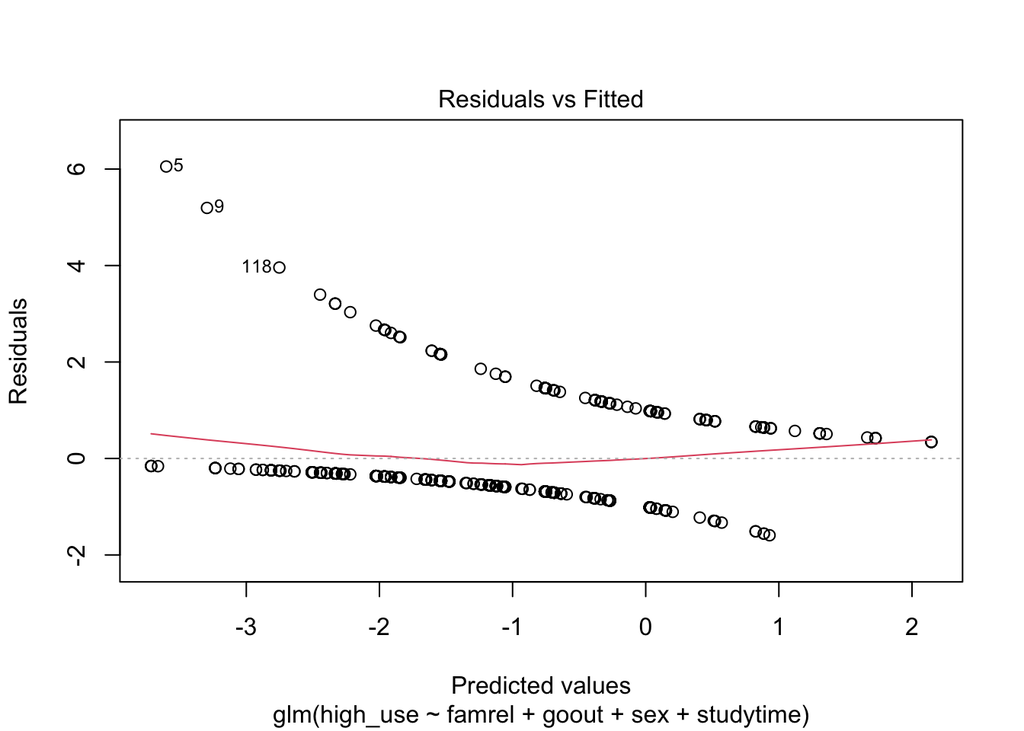

```r
# Plot residuals and check that linearity is OK
plot(model.2, which = 1)  # -> Looks OK.
```

We can also test with ANOVA if null model is significantly different from our model

```r
# see http://homepage.stat.uiowa.edu/~rdecook/stat3200/notes/LogReg_part2_4pp.pdf
# and https://cran.r-project.org/web/packages/HSAUR/vignettes/Ch_logistic_regression_glm.pdf
# and https://stats.stackexchange.com/questions/59879/

# 1-pchisq(model.2$null.deviance-model.2$deviance, model.2$df.null-model.2$df.residual)
null <- glm(high_use ~ 1, family = "binomial", data = alc)
anova(null, model.2, test="Chisq")
```

```
## Analysis of Deviance Table
##
## Model 1: high_use ~ 1
## Model 2: high_use ~ famrel + goout + sex + studytime
##   Resid. Df Resid. Dev Df Deviance  Pr(>Chi)
## 1       369     452.04
## 2       365     370.69  4   81.354 < 2.2e-16 ***
## ---
## Signif. codes:  0 '***' 0.001 '**' 0.01 '*' 0.05 '.' 0.1 ' ' 1
```

We conclude that at least one of the explanatory variables has non-zero coefficient by this test.

### Compute odds ratios and confidence intervals

```r
OR <- coef(model.2) %>% exp
CI <- confint(model.2) %>% exp

list(OR = OR, CI = CI)
```

```
## $OR
## (Intercept)      famrel       goout        sexM   studytime
##   0.2816141   0.6575181   2.1974324   2.2165443   0.6179355
##
## $CI
##                  2.5 %    97.5 %
## (Intercept) 0.06545486 1.1622100
## famrel      0.49791884 0.8636137
## goout       1.73873662 2.8198312
## sexM        1.31841735 3.7630180
## studytime   0.43751933 0.8576353
```

The odds ratio for `famrel` is 0.66 and 95% CI is [0.50, 0.86]. Thus, increase by 1 unit in `famrel` is associated with a decrease in the odds of `high_use` by 14-50%.

Variables `goout` (increases `high_use` odds) and `studytime` (decreases `high_use` odds) are interpreted analogously and neither containts 1 in the 95% CI.

The `sexM` is interpreted in relation to implicit `sexF`: being male increases the `high_use` odds by around 122% with 95% CI of [1.32, 3.76].

It seems that the results correspond to the hypotheses. It feels like `famrel` would require more work although the interaction term of `sex`*`famrel` is not significant when added to `model.2` (data not shown).

## Predictive power

```r
observed <- alc$high_use
predicted <- predict(model.2, type = "response") > 0.5

# 2x2 tabulation, confusion matrix
table(observed, predicted)
```

```
##         predicted
## observed FALSE TRUE
##    FALSE   230   29
##    TRUE     59   52
```

Most cases are classified correctly.

Below are the predictions versus actual `high_use` values, plotted separately for each explanatory variable.

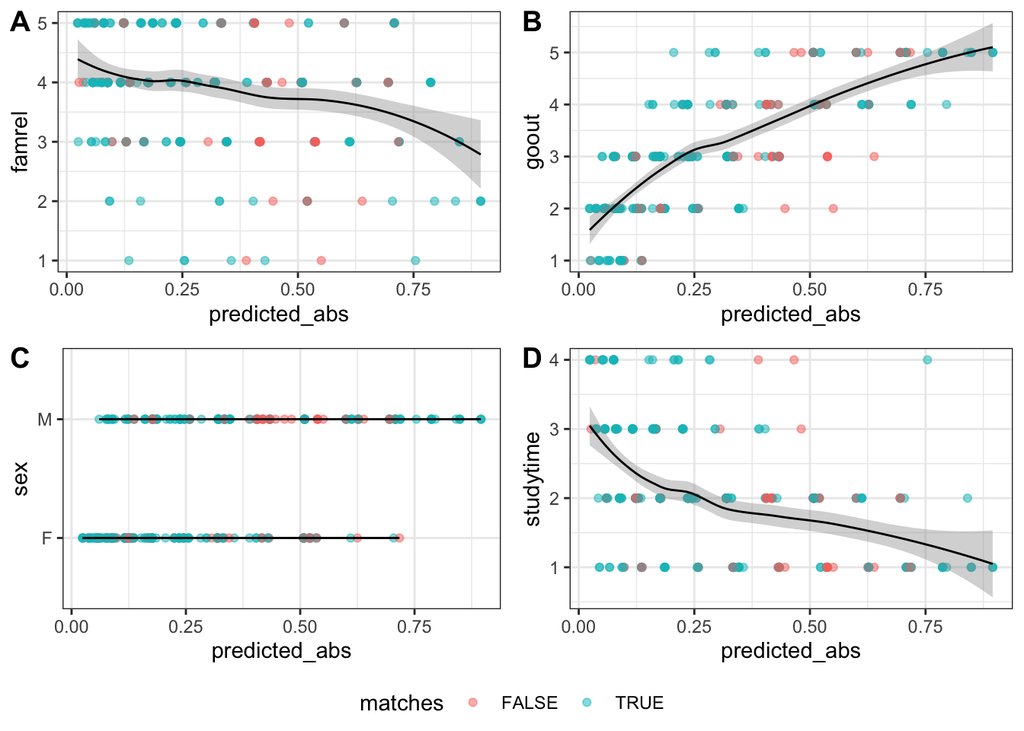

```r
# Get predictions, compare against true values
predicted_abs <- predict(model.2, type = "response")

df <- data.frame(cbind(observed, predicted, predicted_abs,
                       alc[, interesting_vars[3:6]]))

df$matches <- df$observed == df$predicted

# Plot by explanatory variables
prob.expl <- function(df, ind.var, expl.var, col.var) {

  g <- ggplot(df, aes(x = .data[[ind.var]],
                      y = .data[[expl.var]])) +
    geom_point(alpha = 0.5, aes(col = .data[[col.var]])) +
    geom_smooth(method = "loess", col = "black", size = 0.5) +
    theme_bw()
  g
}

g1 <- prob.expl(df, "predicted_abs", "famrel", "matches")
g2 <- prob.expl(df, "predicted_abs", "goout", "matches")
g3 <- prob.expl(df, "predicted_abs", "sex", "matches")
g4 <- prob.expl(df, "predicted_abs", "studytime", "matches")

ggarrange(g1, g2, g3, g4, ncol = 2, nrow = 2, labels = c("A", "B", "C", "D"),
          common.legend = TRUE, legend = "bottom")
```

From the plot above we see where the predictions of `high_use`are right (greenish points) and wrong (red points). For `famrel` (A), `sex` (C) and `studytime` (D), the predictions seem to be false mostly around probability 0.5. With `goout`, `high_use` appears to be poorly predicted when `goout` is low and predicted value is in the range of [0.5, 0.7].

Quantify at which probability values mismatches tend to occur:

```r
# Predictions equal observation
round(table(cut_interval(df[df$matches == TRUE, c("predicted_abs")], length=0.20)) /
  length(df$matches), 2)
```

```
##
##   [0,0.2] (0.2,0.4] (0.4,0.6] (0.6,0.8]   (0.8,1]
##      0.36      0.22      0.08      0.08      0.02
```

```r
# False predictions
round(table(cut_interval(df[df$matches == FALSE, c("predicted_abs")], length=0.20)) /
  length(df$matches), 2)
```

```
##
##   [0,0.2] (0.2,0.4] (0.4,0.6] (0.6,0.8]
##      0.06      0.05      0.10      0.03
```

This confirms that most false predictions are made around the probability 0.5.

The training error of the model is 0.24, i.e. lowish. If we just guessed using, say, `goout`, the error would be around 0.28, which is not very bad. Of course the guessing is not very random, since we already know that `goout` is an important predictor.

```r
# Training error, model.2
sum(df$matches == FALSE) / length(df$matches)
```

```
## [1] 0.2378378
```

```r
# Guess high_use by goout
guesses <- rep(FALSE, times = nrow(df))
guesses[df$goout > mean(df$goout)] <- TRUE

table(df$observed, guesses)
```

```
##        guesses
##         FALSE TRUE
##   FALSE   198   61
##   TRUE     41   70
```

```r
sum(guesses != df$observed) / nrow(df)
```

```
## [1] 0.2756757
```

## Cross-validation

Follow the code in DataCamp for this one

```r
# define a loss function (average prediction error)
loss_func <- function(class, prob) {
  n_wrong <- abs(class - prob) > 0.5
  mean(n_wrong)
}

# compute the average number of wrong predictions in the (training) data
loss_func(alc$high_use, df$predicted_abs)
```

```
## [1] 0.2378378
```

```r
# K-fold cross-validation
library(boot)
cv <- cv.glm(data = alc, cost = loss_func, glmfit = model.2, K = 10)

# average number of wrong predictions in the cross validation
cv$delta[1]
```

```
## [1] 0.2432432
```

## Simple model selection

```r
# Select all explanatory variables available
training.vars <- colnames(alc)[1:36] # Discard non-joined .m and .p variables

# Discard alcohol consumption variables and technical variables
training.vars <- training.vars[!(
  training.vars %in% c("Dalc", "Walc", "n", "id.p", "id.m"))]
```

Now, with enough compute we could just try all the variables, but that would amount to 2^32 = 4294967296 models. We instead use stepwise selection by AIC starting with the full model and progressing backwards. We also assume R handles the factor variable to dummy (treatment) encoding. (Note the [problems](https://journalofbigdata.springeropen.com/articles/10.1186/s40537-018-0143-6) of stepwise regression. It would be advisable to use other methods e.g. through Caret.)

```r
library(MASS)

# Run stepwise AIC selection on full model, keep the model and its AIC
final.m <- stepAIC(
  # Full model
  glm(paste0("high_use", " ~ ", paste(training.vars[-1], collapse=" + ")),
             family = binomial, data = alc),
  direction = "backward", trace = FALSE,
  # What to keep from models
  keep = function(model, aic) { list(model = model, aic = aic) } )
```

Then perform 10-fold CV for the models

```r
# Init
CVs  <- rep(NULL, ncol(final.m$keep))  # Test error
ERRs <- rep(NULL, ncol(final.m$keep))  # Train error
AICs <- rep(NULL, ncol(final.m$keep))
Nvar <- rep(NULL, ncol(final.m$keep))

for (i in 1:ncol(final.m$keep)) {

  interim.m <- final.m$keep[, i][1]$model
  CVs[i] <- cv.glm(data = alc, cost = loss_func, glmfit = interim.m, K = 10)$delta[1]

  ERRs[i] <- loss_func(alc$high_use, predict(interim.m, type = "response"))

  AICs[i] <- final.m$keep[, i][2]$aic

  Nvar[i] <- length(final.m$keep[, i][1]$model$coefficients) - 1
}

CV.res <- data.frame(test = CVs, train = ERRs, AIC = AICs, Nvar = Nvar)
```

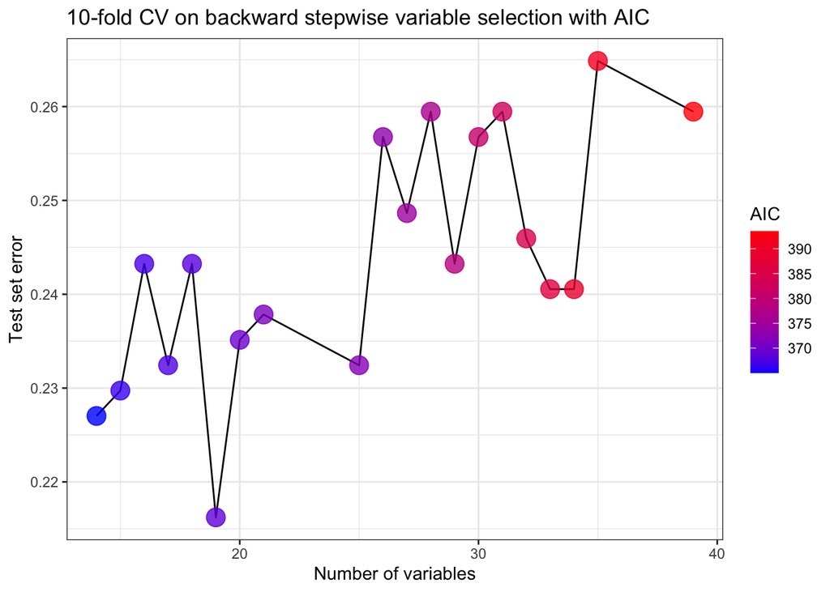

```r
# Somewhat bad graph with points

g1 <- ggplot(CV.res, aes(x = Nvar, y = test)) + geom_line() +
  geom_point(aes(x = Nvar, y = test, color = AIC), size = 5, alpha = 0.8) +
  theme_bw() +  xlab("Number of variables") + ylab("Test set error") +
  ggtitle("10-fold CV on backward stepwise variable selection with AIC") +
  scale_color_gradient(low="blue", high="red")

g1
```

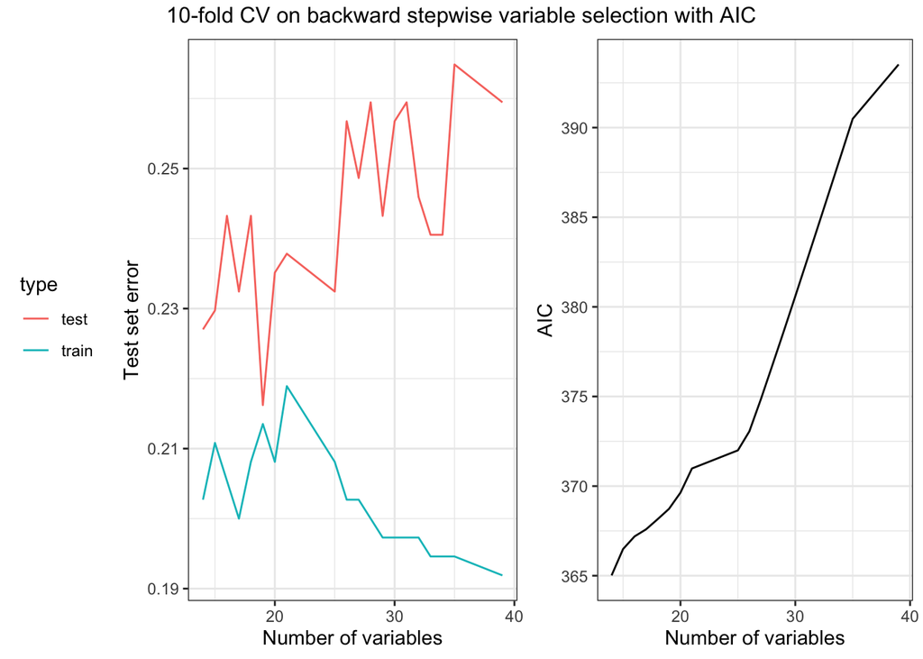

```r
# Better graph with both test and training error, and AIC separately

errors <- gather(CV.res, type, error, c("test", "train"))

g1 <- ggplot(errors, aes(x = Nvar, color = type)) + geom_line(aes(y = error)) +
  theme_bw() +  xlab("Number of variables") + ylab("Test set error")

g2 <- ggplot(errors, aes(x = Nvar)) + geom_line(aes(y = AIC)) +
  theme_bw() +  xlab("Number of variables") + ylab("AIC")

g <- ggarrange(g1, g2, ncol = 2, nrow = 1, widths = c(2, 1.5),
          common.legend = FALSE, legend = "left")

annotate_figure(g, top = text_grob("10-fold CV on backward stepwise variable selection with AIC"))
```

The final model was

```r
summary(final.m)
```

```
##
## Call:
## glm(formula = high_use ~ sex + address + famsize + reason + guardian +
##     activities + romantic + famrel + goout + health + absences,
##     family = binomial, data = alc)
##
## Deviance Residuals:
##     Min       1Q   Median       3Q      Max
## -1.8167  -0.7154  -0.4262   0.5635   2.7612
##
## Coefficients:
##                  Estimate Std. Error z value Pr(>|z|)
## (Intercept)      -2.14937    0.86318  -2.490 0.012772 *
## sexM              0.98275    0.28722   3.422 0.000623 ***
## addressU         -0.89491    0.33661  -2.659 0.007847 **
## famsizeLE3        0.47009    0.29971   1.569 0.116759
## reasonhome        0.31183    0.35612   0.876 0.381229
## reasonother       1.24517    0.47895   2.600 0.009328 **
## reasonreputation -0.28654    0.36969  -0.775 0.438278
## guardianmother   -0.68303    0.32428  -2.106 0.035179 *
## guardianother     0.41726    0.71637   0.582 0.560256
## activitiesyes    -0.51481    0.28383  -1.814 0.069710 .
## romanticyes      -0.50684    0.30464  -1.664 0.096171 .
## famrel           -0.50627    0.15580  -3.249 0.001156 **
## goout             0.91148    0.13829   6.591 4.36e-11 ***
## health            0.16738    0.10359   1.616 0.106138
## absences          0.09152    0.02373   3.856 0.000115 ***
## ---
## Signif. codes:  0 '***' 0.001 '**' 0.01 '*' 0.05 '.' 0.1 ' ' 1
##
## (Dispersion parameter for binomial family taken to be 1)
##
##     Null deviance: 452.04  on 369  degrees of freedom
## Residual deviance: 335.02  on 355  degrees of freedom
## AIC: 365.02
##
## Number of Fisher Scoring iterations: 5
```

```r
parsimonious.m <- glm(formula = high_use ~ sex + address + reason + guardian +
    activities + famrel + goout + absences, family = binomial, data = alc)

summary(parsimonious.m)
```

```
##
## Call:
## glm(formula = high_use ~ sex + address + reason + guardian +
##     activities + famrel + goout + absences, family = binomial,
##     data = alc)
##
## Deviance Residuals:
##     Min       1Q   Median       3Q      Max
## -1.8386  -0.7558  -0.4676   0.6257   2.8133
##
## Coefficients:
##                  Estimate Std. Error z value Pr(>|z|)
## (Intercept)      -1.65723    0.77828  -2.129 0.033225 *
## sexM              1.09542    0.27999   3.912 9.14e-05 ***
## addressU         -0.84765    0.33097  -2.561 0.010435 *
## reasonhome        0.24841    0.34895   0.712 0.476533
## reasonother       1.06110    0.46814   2.267 0.023412 *
## reasonreputation -0.35044    0.36541  -0.959 0.337531
## guardianmother   -0.65433    0.31871  -2.053 0.040071 *
## guardianother     0.27975    0.69303   0.404 0.686459
## activitiesyes    -0.55234    0.28067  -1.968 0.049075 *
## famrel           -0.45739    0.15011  -3.047 0.002311 **
## goout             0.87831    0.13550   6.482 9.06e-11 ***
## absences          0.08739    0.02335   3.743 0.000182 ***
## ---
## Signif. codes:  0 '***' 0.001 '**' 0.01 '*' 0.05 '.' 0.1 ' ' 1
##
## (Dispersion parameter for binomial family taken to be 1)
##
##     Null deviance: 452.04  on 369  degrees of freedom
## Residual deviance: 341.90  on 358  degrees of freedom
## AIC: 365.9
##
## Number of Fisher Scoring iterations: 5
```

```r
loss_func(alc$high_use, predict(parsimonious.m, type = "response"))
```

```
## [1] 0.1972973
```

```r
cv.glm(data = alc, cost = loss_func, glmfit = parsimonious.m, K = 10)$delta[1]
```

```
## [1] 0.2324324
```